# Investigating How Clothing style vary by Season

## Brand Visibility by Style: What Your Outfit Says About You

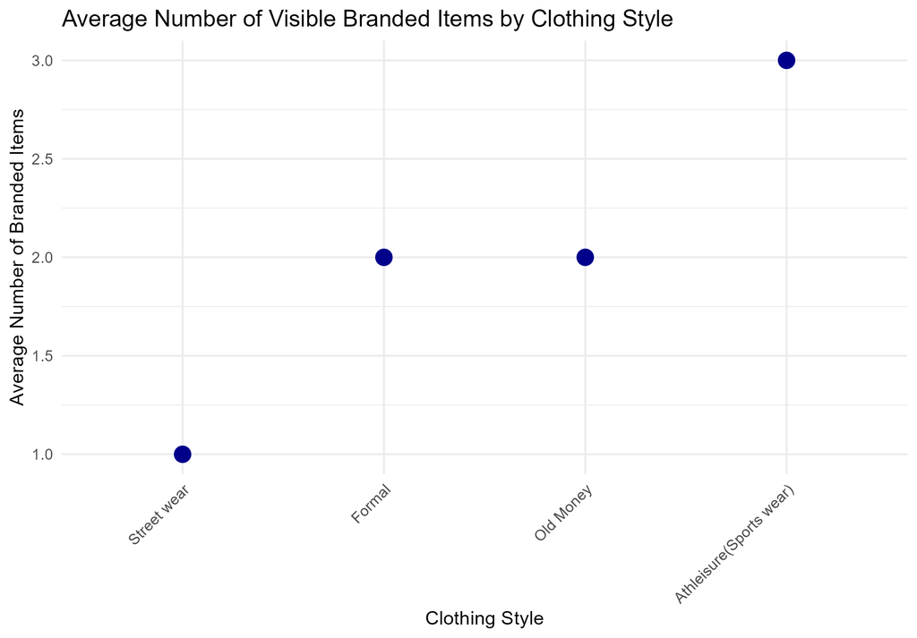

Athleisure (Sportswear) takes the lead, boldly shouting its name in the guise of giant logos and easily recognizable brand symbols. Branding here isn’t merely observed—it’s the uniform. It is a reflection of a society where image and performance are equated.

Formal and Old Money styles reside at the midpoints, leaning towards subtle refinement. Their branding is less self-advertising—perhaps a well-tailored suit with a discreet insignia or a luxury handbag whose excellence lies beyond any brand name. In those situations, refinement lies in what is unspoken.

And then there’s Street wear, the subtle revolutionist. Paradoxically, it shows the lowest mean number of branded elements, reflecting the taste that stresses individuality at the expense of corporate branding. Individuality prefers to overcome the desire to expose brand allegiance here.

Overall, they remind us that fashion’s not just about what you’re wearing—it’s about a message. Whatever it is you’re getting dressed for, your engagement with brand speaks volumes about who you are. And in such fashions as Athleisure, that engagement takes center stage.

## Layer Up or Strip Down: How Weather Shapes Our Outfits

[figure not shown]

In general, the weather forecast might not dictate your sense of style—but it definitely makes you feel comfortable in it.

## Accessorize with the Weather: What’s Hot and What’s Not

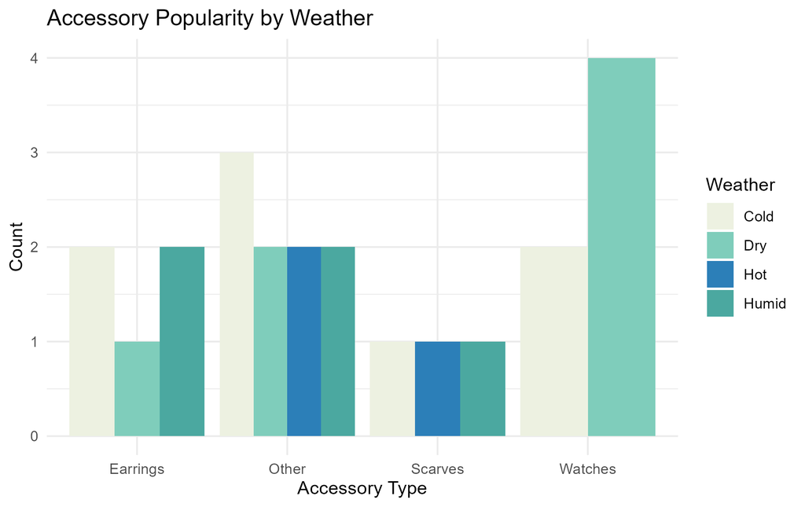

## Trend Walk: How Footwear Styles Change Each Month

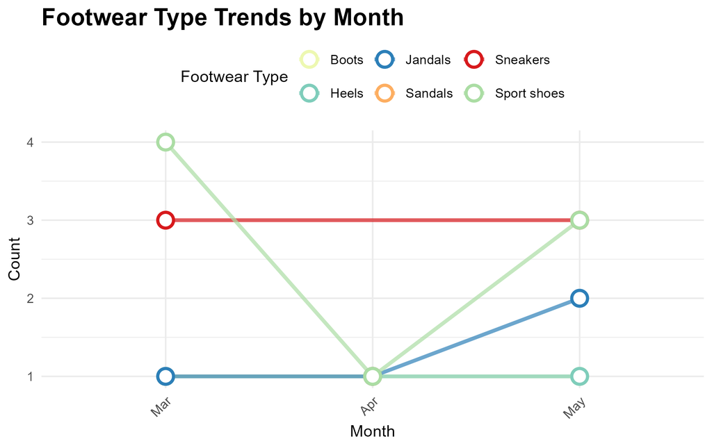

Looking at this graph, it’s pretty clear we’re seeing seasonal shoe trends in action! Sport shoes take a wild ride - super popular in March, then drop way down in April before climbing back up in May. Guess people’s workout routines change with the weather! Sneakers are the reliable friend here, staying steady at 3 units all three months - people love their everyday kicks no matter what. Jandals are slowly making their comeback as summer approaches, while heels just hang out at minimal levels throughout. Interestingly, boots and sandals don’t show up at all during these months - we’re catching that awkward in-between season when it’s not quite cold enough for boots but not warm enough for full sandal weather yet. It’s cool to see how our footwear naturally shifts from closed-toe to more open styles as the temperature climbs!

## In conclusion

[figure not shown]

Along the route, I learned how weather determines accessories, how footwear varies by month, and how brands capture style personalities. Through some simple data transformations and plots, I gained more insight into fashion’s trends. While my results are specific to my observations and could contain some bias, this activity illustrates how data logging and visualization can reveal trends to make style decisions more informed.